# MA615_HW2_Ioslides

9/20/2019

## Class assignment:

Using the MPG dataset, which is available with the ggplot2 library, produce a document that includes the following elements: headers, text, tables, and plots.

Tables should include a comparison of city and highway mileage by the class of car and the best three car models for city and highway mileage for all the years in which data is available.

Plot the data displaying as much of the data as you can. Put continuous variables on the axes and include a locally smoothed regression line to show the relationship with mileage. Also make a box plot comparing city and highway MPG by class of car.

## Table One

| class | City MPG | Highway MPG |
| --- | --- | --- |
| subcompact | 20.37 | 28.14 |
| compact | 20.13 | 28.30 |
| midsize | 18.76 | 27.29 |
| minivan | 15.82 | 22.36 |
| 2seater | 15.40 | 24.80 |
| suv | 13.50 | 18.13 |
| pickup | 13.00 | 16.88 |

## Table Two

the best three car models for city and highway mileage for all the years

| City 1999 model | City 1999 City | Highway 1999 model | Highway 1999 Highway | City 2008 model | City 2008 City | Highway 2008 model | Highway 2008 Highway |
| --- | --- | --- | --- | --- | --- | --- | --- |
| new beetle | 26.00 | new beetle | 35.00 | corolla | 27.0 | corolla | 36.00 |
| civic | 24.80 | corolla | 32.67 | civic | 24.0 | civic | 33.75 |
| corolla | 24.67 | civic | 31.60 | gti | 21.5 | gti | 29.00 |

## Plot One

Plot the data displying as much of the data as you can. Put continuous variables on the axes and include a locally smoothed regression line to show the relationship with mileage.

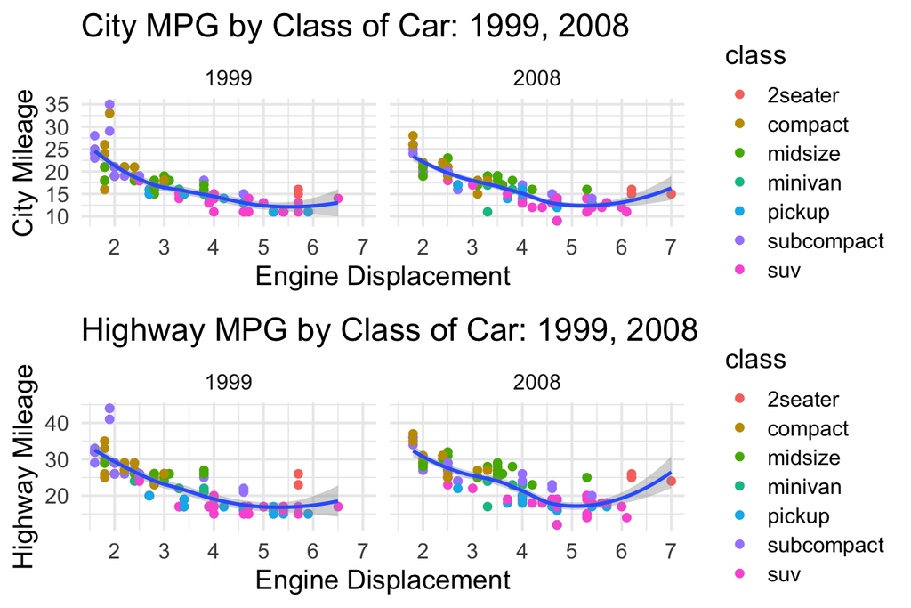

## Plot Two

a box plot comparing city and highway MPG by class of car

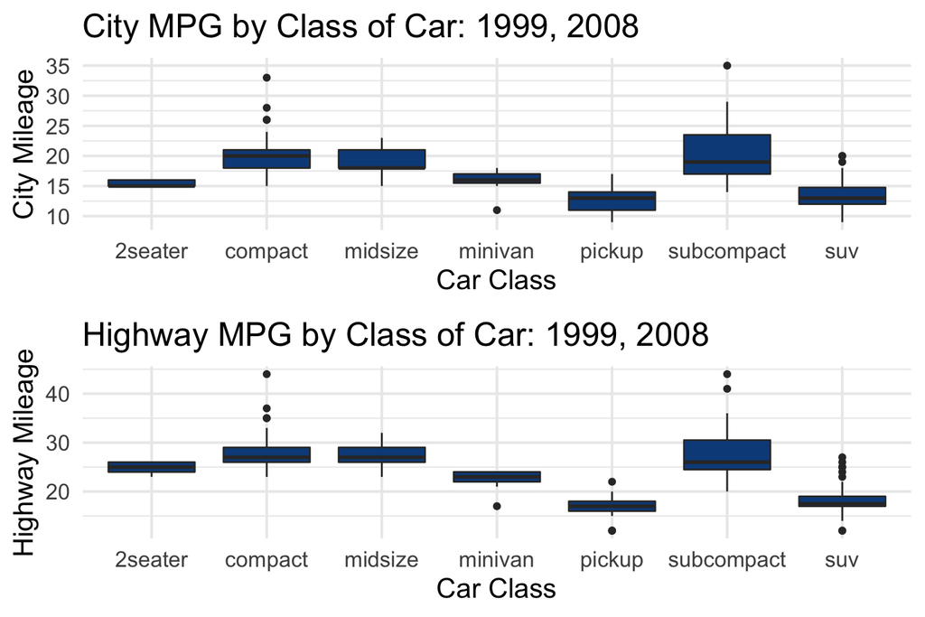